> **Tip**: Welcome to the Investigate a Dataset project! You will find tips in quoted sections like this to help organize your approach to your investigation. Before submitting your project, it will be a good idea to go back through your report and remove these sections to make the presentation of your work as tidy as possible. First things first, you might want to double-click this Markdown cell and change the title so that it reflects your dataset and investigation.

# Project: Investigate a Dataset - TMDB Movie

- Introduction
- Data Wrangling
- Exploratory Data Analysis
- Conclusions

## Introduction

#### About Data :-

###### Data set choosed is TMDB movie data, which has information of movies collected from the movie database (TMDB) including the user ratings and revenue.

#### Analysis :-

##### This project will try to analyze

##### 1) Which are the genres have got most popularity

##### 2) movie which has got high revenues - attributes

```python
# Use this cell to set up import statements for all of the packages that you
#   plan to use.
import pandas as pd
import numpy as np
% matplotlib inline
import matplotlib.pyplot as plt
import seaborn as sns

# Remember to include a 'magic word' so that your visualizations are plotted
#   inline with the notebook. See this page for more:
#   http://ipython.readthedocs.io/en/stable/interactive/magics.html
```

## Data Wrangling

> **Tip**: In this section of the report, you will load in the data, check for cleanliness, and then trim and clean your dataset for analysis. Make sure that you document your steps carefully and justify your cleaning decisions.

### General Properties

```python
# Load your data and print out a few lines. Perform operations to inspect data
#   types and look for instances of missing or possibly errant data.
movie=pd.read_csv('tmdb-movies.csv')
movie.info()
```

```
<class 'pandas.core.frame.DataFrame'>
RangeIndex: 10866 entries, 0 to 10865
Data columns (total 21 columns):
id                      10866 non-null int64
imdb_id                 10856 non-null object
popularity              10866 non-null float64
budget                  10866 non-null int64
revenue                 10866 non-null int64
original_title          10866 non-null object
cast                    10790 non-null object
homepage                2936 non-null object
director                10822 non-null object
tagline                 8042 non-null object
keywords                9373 non-null object
overview                10862 non-null object
runtime                 10866 non-null int64
genres                  10843 non-null object
production_companies    9836 non-null object
release_date            10866 non-null object
vote_count              10866 non-null int64
vote_average            10866 non-null float64
release_year            10866 non-null int64
budget_adj              10866 non-null float64
revenue_adj             10866 non-null float64
dtypes: float64(4), int64(6), object(11)
memory usage: 1.3+ MB
```

```python
movie.head()
```

|  | id | imdb_id | popularity | budget | revenue | original_title | cast | homepage | director | tagline | ... | overview | runtime | genres | production_companies | release_date | vote_count | vote_average | release_year | budget_adj | revenue_adj |
| --- | --- | --- | --- | --- | --- | --- | --- | --- | --- | --- | --- | --- | --- | --- | --- | --- | --- | --- | --- | --- | --- |
| 0 | 135397 | tt0369610 | 32.985763 | 150000000 | 1513528810 | Jurassic World | Chris Pratt\|Bryce Dallas Howard\|Irrfan Khan\|Vi... | http://www.jurassicworld.com/ | Colin Trevorrow | The park is open. | ... | Twenty-two years after the events of Jurassic ... | 124 | Action\|Adventure\|Science Fiction\|Thriller | Universal Studios\|Amblin Entertainment\|Legenda... | 6/9/15 | 5562 | 6.5 | 2015 | 1.379999e+08 | 1.392446e+09 |
| 1 | 76341 | tt1392190 | 28.419936 | 150000000 | 378436354 | Mad Max: Fury Road | Tom Hardy\|Charlize Theron\|Hugh Keays-Byrne\|Nic... | http://www.madmaxmovie.com/ | George Miller | What a Lovely Day. | ... | An apocalyptic story set in the furthest reach... | 120 | Action\|Adventure\|Science Fiction\|Thriller | Village Roadshow Pictures\|Kennedy Miller Produ... | 5/13/15 | 6185 | 7.1 | 2015 | 1.379999e+08 | 3.481613e+08 |
| 2 | 262500 | tt2908446 | 13.112507 | 110000000 | 295238201 | Insurgent | Shailene Woodley\|Theo James\|Kate Winslet\|Ansel... | http://www.thedivergentseries.movie/#insurgent | Robert Schwentke | One Choice Can Destroy You | ... | Beatrice Prior must confront her inner demons ... | 119 | Adventure\|Science Fiction\|Thriller | Summit Entertainment\|Mandeville Films\|Red Wago... | 3/18/15 | 2480 | 6.3 | 2015 | 1.012000e+08 | 2.716190e+08 |
| 3 | 140607 | tt2488496 | 11.173104 | 200000000 | 2068178225 | Star Wars: The Force Awakens | Harrison Ford\|Mark Hamill\|Carrie Fisher\|Adam D... | http://www.starwars.com/films/star-wars-episod... | J.J. Abrams | Every generation has a story. | ... | Thirty years after defeating the Galactic Empi... | 136 | Action\|Adventure\|Science Fiction\|Fantasy | Lucasfilm\|Truenorth Productions\|Bad Robot | 12/15/15 | 5292 | 7.5 | 2015 | 1.839999e+08 | 1.902723e+09 |
| 4 | 168259 | tt2820852 | 9.335014 | 190000000 | 1506249360 | Furious 7 | Vin Diesel\|Paul Walker\|Jason Statham\|Michelle ... | http://www.furious7.com/ | James Wan | Vengeance Hits Home | ... | Deckard Shaw seeks revenge against Dominic Tor... | 137 | Action\|Crime\|Thriller | Universal Pictures\|Original Film\|Media Rights ... | 4/1/15 | 2947 | 7.3 | 2015 | 1.747999e+08 | 1.385749e+09 |

5 rows × 21 columns

```python
# Check for any duplicates present in the data set
sum(movie.duplicated())
```

```
1
```

```python
#Remove the one duplicate present in the dataset
movie.drop_duplicates(inplace=True)
```

```python
#Re-check for the duplicates to ensure
sum(movie.duplicated())
```

```
0
```

```python
#Statistical describe of information in data set
movie.describe()
```

|  | id | popularity | budget | revenue | runtime | vote_count | vote_average | release_year | budget_adj | revenue_adj |
| --- | --- | --- | --- | --- | --- | --- | --- | --- | --- | --- |
| count | 10865.000000 | 10865.000000 | 1.086500e+04 | 1.086500e+04 | 10865.000000 | 10865.000000 | 10865.000000 | 10865.000000 | 1.086500e+04 | 1.086500e+04 |
| mean | 66066.374413 | 0.646446 | 1.462429e+07 | 3.982690e+07 | 102.071790 | 217.399632 | 5.975012 | 2001.321859 | 1.754989e+07 | 5.136900e+07 |
| std | 92134.091971 | 1.000231 | 3.091428e+07 | 1.170083e+08 | 31.382701 | 575.644627 | 0.935138 | 12.813260 | 3.430753e+07 | 1.446383e+08 |
| min | 5.000000 | 0.000065 | 0.000000e+00 | 0.000000e+00 | 0.000000 | 10.000000 | 1.500000 | 1960.000000 | 0.000000e+00 | 0.000000e+00 |
| 25% | 10596.000000 | 0.207575 | 0.000000e+00 | 0.000000e+00 | 90.000000 | 17.000000 | 5.400000 | 1995.000000 | 0.000000e+00 | 0.000000e+00 |
| 50% | 20662.000000 | 0.383831 | 0.000000e+00 | 0.000000e+00 | 99.000000 | 38.000000 | 6.000000 | 2006.000000 | 0.000000e+00 | 0.000000e+00 |
| 75% | 75612.000000 | 0.713857 | 1.500000e+07 | 2.400000e+07 | 111.000000 | 146.000000 | 6.600000 | 2011.000000 | 2.085325e+07 | 3.370173e+07 |
| max | 417859.000000 | 32.985763 | 4.250000e+08 | 2.781506e+09 | 900.000000 | 9767.000000 | 9.200000 | 2015.000000 | 4.250000e+08 | 2.827124e+09 |

> **Tip**: You should *not* perform too many operations in each cell. Create cells freely to explore your data. One option that you can take with this project is to do a lot of explorations in an initial notebook. These don't have to be organized, but make sure you use enough comments to understand the purpose of each code cell. Then, after you're done with your analysis, create a duplicate notebook where you will trim the excess and organize your steps so that you have a flowing, cohesive report.

> **Tip**: Make sure that you keep your reader informed on the steps that you are taking in your investigation. Follow every code cell, or every set of related code cells, with a markdown cell to describe to the reader what was found in the preceding cell(s). Try to make it so that the reader can then understand what they will be seeing in the following cell(s).

### Data Cleaning

```
> Remove unwanted columns, in this case we are dropping columns like ID, homepage, tagline, overview, budget , revenue and keywords which dont have direct impact on our analysis such the data will be short to look upat
```

```python
# After discussing the structure of the data and any problems that need to be
#   cleaned, perform those cleaning steps in the second part of this section.
# Removing unwanted columns from the dataset
movie.drop(['id','homepage','tagline','overview','budget','revenue','keywords'],axis=1,inplace=True)
movie.info()
```

```
<class 'pandas.core.frame.DataFrame'>
Int64Index: 10865 entries, 0 to 10865
Data columns (total 14 columns):
imdb_id                 10855 non-null object
popularity              10865 non-null float64
original_title          10865 non-null object
cast                    10789 non-null object
director                10821 non-null object
runtime                 10865 non-null int64
genres                  10842 non-null object
production_companies    9835 non-null object
release_date            10865 non-null object
vote_count              10865 non-null int64
vote_average            10865 non-null float64
release_year            10865 non-null int64
budget_adj              10865 non-null float64
revenue_adj             10865 non-null float64
dtypes: float64(4), int64(3), object(7)
memory usage: 976.2+ KB
```

```python
#Check for null values present in budget and revenue fields
movie_null_budget=movie.query('(revenue_adj <= 0) or (budget_adj <= 0)')
```

```python
movie_null_budget.count()
```

```
imdb_id                 7001
popularity              7011
original_title          7011
cast                    6939
director                6968
runtime                 7011
genres                  6988
production_companies    6027
release_date            7011
vote_count              7011
vote_average            7011
release_year            7011
budget_adj              7011
revenue_adj             7011
dtype: int64
```

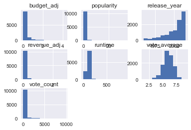

```python
movie.hist();
```

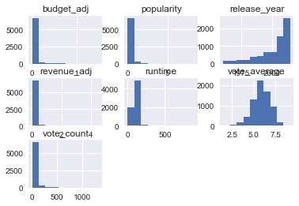

```python
movie_null_budget.hist();
```

```python
#Since significant number of observations are having 0 values in budget and revenue.
#Changing these values from 0 to null, so that these can be excluded while doing statistical operations but stil present in data set
movie.revenue_adj=movie.revenue_adj.replace(0,np.NaN)
movie.budget_adj=movie.budget_adj.replace(0,np.NaN)
movie.info()
```

```
<class 'pandas.core.frame.DataFrame'>
Int64Index: 10865 entries, 0 to 10865
Data columns (total 14 columns):
imdb_id                 10855 non-null object
popularity              10865 non-null float64
original_title          10865 non-null object
cast                    10789 non-null object
director                10821 non-null object
runtime                 10865 non-null int64
genres                  10842 non-null object
production_companies    9835 non-null object
release_date            10865 non-null object
vote_count              10865 non-null int64
vote_average            10865 non-null float64
release_year            10865 non-null int64
budget_adj              5169 non-null float64
revenue_adj             4849 non-null float64
dtypes: float64(4), int64(3), object(7)
memory usage: 976.2+ KB
```

```python
movie.describe()
```

|  | popularity | runtime | vote_count | vote_average | release_year | budget_adj | revenue_adj |
| --- | --- | --- | --- | --- | --- | --- | --- |
| count | 10865.000000 | 10865.000000 | 10865.000000 | 10865.000000 | 10865.000000 | 5.169000e+03 | 4.849000e+03 |
| mean | 0.646446 | 102.071790 | 217.399632 | 5.975012 | 2001.321859 | 3.688907e+07 | 1.151009e+08 |
| std | 1.000231 | 31.382701 | 575.644627 | 0.935138 | 12.813260 | 4.196096e+07 | 1.988557e+08 |
| min | 0.000065 | 0.000000 | 10.000000 | 1.500000 | 1960.000000 | 9.210911e-01 | 2.370705e+00 |
| 25% | 0.207575 | 90.000000 | 17.000000 | 5.400000 | 1995.000000 | 8.102293e+06 | 1.046585e+07 |
| 50% | 0.383831 | 99.000000 | 38.000000 | 6.000000 | 2006.000000 | 2.271505e+07 | 4.395666e+07 |
| 75% | 0.713857 | 111.000000 | 146.000000 | 6.600000 | 2011.000000 | 5.008384e+07 | 1.316482e+08 |
| max | 32.985763 | 900.000000 | 9767.000000 | 9.200000 | 2015.000000 | 4.250000e+08 | 2.827124e+09 |

```python
#Create a data frame with Release Year, Popularity and the Genres (Split) and
##take the mean of popularity by year for each and every genre
genre_list_df = movie[['release_year', 'genres', 'popularity']].copy()
```

```python
genre_list_df.head()
```

|  | release_year | genres | popularity |
| --- | --- | --- | --- |
| 0 | 2015 | Action\|Adventure\|Science Fiction\|Thriller | 32.985763 |
| 1 | 2015 | Action\|Adventure\|Science Fiction\|Thriller | 28.419936 |
| 2 | 2015 | Adventure\|Science Fiction\|Thriller | 13.112507 |
| 3 | 2015 | Action\|Adventure\|Science Fiction\|Fantasy | 11.173104 |
| 4 | 2015 | Action\|Crime\|Thriller | 9.335014 |

```python
#Null records for Genres has been dropped here
genre_list_df=genre_list_df.dropna()
```

```python
genre_list_df.info()
```

```
<class 'pandas.core.frame.DataFrame'>
Int64Index: 10842 entries, 0 to 10865
Data columns (total 3 columns):
release_year    10842 non-null int64
genres          10842 non-null object
popularity      10842 non-null float64
dtypes: float64(1), int64(1), object(1)
memory usage: 296.5+ KB
```

```python
#Split the genre which is having multiple values seperated by "|"
g_part = genre_list_df['genres'].str.split("|", n = 6, expand = True)
```

```python
g_part.head()
```

|  | 0 | 1 | 2 | 3 | 4 |
| --- | --- | --- | --- | --- | --- |
| 0 | Action | Adventure | Science Fiction | Thriller | None |
| 1 | Action | Adventure | Science Fiction | Thriller | None |
| 2 | Adventure | Science Fiction | Thriller | None | None |
| 3 | Action | Adventure | Science Fiction | Fantasy | None |
| 4 | Action | Crime | Thriller | None | None |

```python
#Adding each and everyvalue from the genre
genre_list_df["genre_1"]=g_part[0]
genre_list_df["genre_2"]=g_part[1]
genre_list_df["genre_3"]=g_part[2]
genre_list_df["genre_4"]=g_part[3]
genre_list_df["genre_5"]=g_part[4]
```

```python
genre_list_df.head()
```

|  | release_year | genres | popularity | genre_1 | genre_2 | genre_3 | genre_4 | genre_5 |
| --- | --- | --- | --- | --- | --- | --- | --- | --- |
| 0 | 2015 | Action\|Adventure\|Science Fiction\|Thriller | 32.985763 | Action | Adventure | Science Fiction | Thriller | None |
| 1 | 2015 | Action\|Adventure\|Science Fiction\|Thriller | 28.419936 | Action | Adventure | Science Fiction | Thriller | None |
| 2 | 2015 | Adventure\|Science Fiction\|Thriller | 13.112507 | Adventure | Science Fiction | Thriller | None | None |
| 3 | 2015 | Action\|Adventure\|Science Fiction\|Fantasy | 11.173104 | Action | Adventure | Science Fiction | Fantasy | None |
| 4 | 2015 | Action\|Crime\|Thriller | 9.335014 | Action | Crime | Thriller | None | None |

```python
#Transposing a dataset to summarize the data to get the mean value of popularity
genre_list_df2=pd.wide_to_long(genre_list_df, stubnames='genre', i=['release_year', 'popularity'],j='genre_no' ,sep='_', suffix='\w')
genre_list_df2.reset_index(inplace=True)
```

```python
genre_list_df2.head()
```

|  | release_year | popularity | genre_no | genres | genre |
| --- | --- | --- | --- | --- | --- |
| 0 | 2015 | 32.985763 | 1 | Action\|Adventure\|Science Fiction\|Thriller | Action |
| 1 | 2015 | 32.985763 | 2 | Action\|Adventure\|Science Fiction\|Thriller | Adventure |
| 2 | 2015 | 32.985763 | 3 | Action\|Adventure\|Science Fiction\|Thriller | Science Fiction |
| 3 | 2015 | 32.985763 | 4 | Action\|Adventure\|Science Fiction\|Thriller | Thriller |
| 4 | 2015 | 32.985763 | 5 | Action\|Adventure\|Science Fiction\|Thriller | None |

## Exploratory Data Analysis

> **Tip**: Now that you've trimmed and cleaned your data, you're ready to move on to exploration. Compute statistics and create visualizations with the goal of addressing the research questions that you posed in the Introduction section. It is recommended that you be systematic with your approach. Look at one variable at a time, and then follow it up by looking at relationships between variables.

### Research Question 1 (Which are the genres have got most popularity?)

```python
#Group by two parameters to get the mean value of popularity
#Also do the count on genre to take the top values
genre_list_mean_df2=genre_list_df2.groupby(['release_year','genre'])['popularity']. mean().reset_index()
genre_list_count_df2=genre_list_df2.groupby(['genre'])['popularity']. count().reset_index()
genre_list_count_df_tot=genre_list_df2.groupby(['release_year','genre'])['popularity']. count().reset_index()
```

```python
genre_list_mean_df2.head()
#genre_list_count_df2.head(10)
```

|  | release_year | genre | popularity |
| --- | --- | --- | --- |
| 0 | 1960 | Action | 0.590724 |
| 1 | 1960 | Adventure | 0.700981 |
| 2 | 1960 | Comedy | 0.396000 |
| 3 | 1960 | Crime | 0.346480 |
| 4 | 1960 | Drama | 0.566305 |

```python
#To get the 75% of value of popularity for all the genres to select only top values
genre_list_count_df2.describe()
```

|  | popularity |
| --- | --- |
| count | 20.000000 |
| mean | 1347.750000 |
| std | 1260.308228 |
| min | 165.000000 |
| 25% | 389.500000 |
| 50% | 1072.500000 |
| 75% | 1655.750000 |
| max | 4760.000000 |

```python
#select only the genres which are having more than 75% of count
genre_list_count_df2=genre_list_count_df2.query('popularity >= 1655')
```

```python
#select only the genres which are having more than 75% of count
genre_list_mean_df3=pd.merge(genre_list_count_df2,genre_list_mean_df2,on='genre')
```

```python
genre_list_mean_df3=genre_list_mean_df3.pivot(index='release_year', columns='genre', values='popularity_y')
```

```python
genre_list_count_df3.head()
```

[output not shown]

```python
genre_list_count_df4 = genre_list_count_df3[['genre', 'release_year', 'popularity_x']].copy()
```

```python
genre_list_count_df4.head()
```

|  | genre | release_year | popularity_x |
| --- | --- | --- | --- |
| 0 | Action | 1960 | 2384 |
| 1 | Action | 1961 | 2384 |
| 2 | Action | 1962 | 2384 |
| 3 | Action | 1963 | 2384 |
| 4 | Action | 1964 | 2384 |

```python
genre_list_count_df5=genre_list_count_df_tot.pivot(index='release_year', columns='genre', values='popularity')
```

```python
genre_list_count_df5.head()
```

| genre release_year | Action | Adventure | Animation | Comedy | Crime | Documentary | Drama | Family | Fantasy | Foreign | History | Horror | Music | Mystery | Romance | Science Fiction | TV Movie | Thriller | War | Western |
| --- | --- | --- | --- | --- | --- | --- | --- | --- | --- | --- | --- | --- | --- | --- | --- | --- | --- | --- | --- | --- |
| 1960 | 8.0 | 5.0 | NaN | 8.0 | 2.0 | NaN | 13.0 | 3.0 | 2.0 | 1.0 | 5.0 | 7.0 | 1.0 | NaN | 6.0 | 3.0 | NaN | 6.0 | 2.0 | 6.0 |
| 1961 | 7.0 | 6.0 | 1.0 | 10.0 | 2.0 | NaN | 16.0 | 5.0 | 2.0 | 1.0 | 3.0 | 3.0 | 2.0 | 1.0 | 7.0 | 4.0 | NaN | NaN | 2.0 | 3.0 |
| 1962 | 8.0 | 7.0 | NaN | 5.0 | 3.0 | NaN | 21.0 | 2.0 | 1.0 | 1.0 | 4.0 | 5.0 | 1.0 | 4.0 | 5.0 | 2.0 | NaN | 7.0 | 3.0 | 3.0 |
| 1963 | 4.0 | 7.0 | 1.0 | 13.0 | 4.0 | NaN | 13.0 | 3.0 | 2.0 | 2.0 | 4.0 | 9.0 | NaN | 6.0 | 8.0 | 2.0 | NaN | 10.0 | 1.0 | 2.0 |
| 1964 | 5.0 | 5.0 | 2.0 | 16.0 | 10.0 | NaN | 20.0 | 4.0 | 4.0 | 1.0 | 3.0 | 6.0 | 5.0 | 4.0 | 9.0 | 4.0 | NaN | 9.0 | 3.0 | 1.0 |

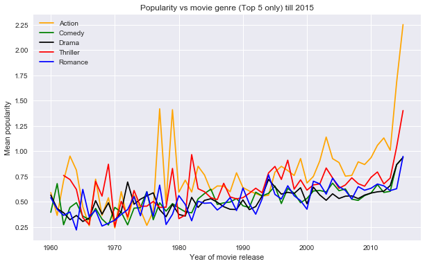

```python
# Use this, and more code cells, to explore your data. Don't forget to add
#   Markdown cells to document your observations and findings.
fig = plt.figure(figsize=(10,6))
plt.plot('Action', data=genre_list_mean_df3, color='orange',label="Action");
plt.plot('Comedy', data=genre_list_mean_df3, color='green',label="Comedy");
plt.plot('Drama', data=genre_list_mean_df3, color='black',label="Drama");
plt.plot('Thriller', data=genre_list_mean_df3, color='red',label="Thriller");
plt.plot('Romance', data=genre_list_mean_df3, color='blue',label="Romance");
plt.xlabel('Year of movie release');
plt.ylabel('Mean popularity');
plt.title('Popularity vs movie genre (Top 5 only) till 2015');
plt.legend();
```

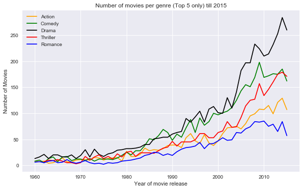

```python
#   Markdown cells to document your observations and findings.
fig = plt.figure(figsize=(10,6))
plt.plot('Action', data=genre_list_count_df5, color='orange',label="Action");
plt.plot('Comedy', data=genre_list_count_df5, color='green',label="Comedy");
plt.plot('Drama', data=genre_list_count_df5, color='black',label="Drama");
plt.plot('Thriller', data=genre_list_count_df5, color='red',label="Thriller");
plt.plot('Romance', data=genre_list_count_df5, color='blue',label="Romance");
plt.xlabel('Year of movie release');
plt.ylabel('Number of Movies');
plt.title('Number of movies per genre (Top 5 only) till 2015');
plt.legend();
```

### Analysis findings

From the above analysis, we can identify that

1) Popularity has been increasing across multiple genres of movies

3) Sudden spike of popularity during late 1970's and early 1980's for "Action" & "Thriller" movies

### Research Question 2 (movie which has got high revenues - attributes)

```python
#Considering only the records which are having revenue and budget more than $0
movie_valid_budget=movie.query('(revenue_adj > 0) or (budget_adj > 0)')
```

```python
movie_valid_budget.describe()
```

|  | popularity | runtime | vote_count | vote_average | release_year | budget_adj | revenue_adj |
| --- | --- | --- | --- | --- | --- | --- | --- |
| count | 6164.000000 | 6164.000000 | 6164.000000 | 6164.000000 | 6164.000000 | 5.169000e+03 | 4.849000e+03 |
| mean | 0.909417 | 106.453926 | 355.941110 | 6.039163 | 2000.984263 | 3.688907e+07 | 1.151009e+08 |
| std | 1.240855 | 23.155724 | 733.220129 | 0.872564 | 11.917284 | 4.196096e+07 | 1.988557e+08 |
| min | 0.001117 | 0.000000 | 10.000000 | 1.500000 | 1960.000000 | 9.210911e-01 | 2.370705e+00 |
| 25% | 0.322289 | 93.000000 | 31.000000 | 5.500000 | 1994.000000 | 8.102293e+06 | 1.046585e+07 |
| 50% | 0.570484 | 102.000000 | 95.500000 | 6.100000 | 2004.000000 | 2.271505e+07 | 4.395666e+07 |
| 75% | 1.050621 | 116.000000 | 324.000000 | 6.600000 | 2010.000000 | 5.008384e+07 | 1.316482e+08 |
| max | 32.985763 | 705.000000 | 9767.000000 | 8.400000 | 2015.000000 | 4.250000e+08 | 2.827124e+09 |

```python
#Create a user defined function to split the value of Revenue column in to bins to analyze properly
def create_bins(df,field):
    min_val = df[field].min()
    _25_val = df[field].describe()[4]
    median = df[field].describe()[5]
    _75_val = df[field].describe()[6]
    max_val = df[field].max()
    bin_edges = [ min_val, _25_val, median, _75_val, max_val]
    bin_names = [ 'Low','Med' ,'Moderately High' ,'High' ]
    name = '{}_bin'.format(field)
    df[name]=pd.cut(df[field], bin_edges, labels=bin_names)
    return df
```

```python
create_bins(movie_valid_budget,'revenue_adj')
create_bins(movie_valid_budget,'budget_adj')
```

[output not shown]

6164 rows × 16 columns

```python
movie_valid_budget.groupby(['revenue_adj_bin']).count().reset_index()
```

|  | revenue_adj_bin | imdb_id | popularity | original_title | cast | director | runtime | genres | production_companies | release_date | vote_count | vote_average | release_year | budget_adj | revenue_adj | budget_adj_bin |
| --- | --- | --- | --- | --- | --- | --- | --- | --- | --- | --- | --- | --- | --- | --- | --- | --- |
| 0 | Low | 1212 | 1212 | 1212 | 1208 | 1212 | 1212 | 1212 | 1128 | 1212 | 1212 | 1212 | 1212 | 696 | 1212 | 696 |
| 1 | Med | 1212 | 1212 | 1212 | 1211 | 1211 | 1212 | 1212 | 1205 | 1212 | 1212 | 1212 | 1212 | 939 | 1212 | 939 |
| 2 | Moderately High | 1212 | 1212 | 1212 | 1212 | 1212 | 1212 | 1212 | 1207 | 1212 | 1212 | 1212 | 1212 | 1058 | 1212 | 1058 |
| 3 | High | 1212 | 1212 | 1212 | 1212 | 1212 | 1212 | 1212 | 1212 | 1212 | 1212 | 1212 | 1212 | 1160 | 1212 | 1160 |

```python
#Create a data frame with Release Year, Popularity and the Genres (Split) and
##take the mean of popularity by year for each and every genre
movie_valid_df = movie_valid_budget[['release_year', 'revenue_adj_bin','budget_adj_bin',  'vote_average','popularity']].copy()
```

```python
movie_valid_df.head()
```

|  | release_year | revenue_adj_bin | budget_adj_bin | vote_average | popularity |
| --- | --- | --- | --- | --- | --- |
| 0 | 2015 | High | High | 6.5 | 32.985763 |
| 1 | 2015 | High | High | 7.1 | 28.419936 |
| 2 | 2015 | High | High | 6.3 | 13.112507 |
| 3 | 2015 | High | High | 7.5 | 11.173104 |
| 4 | 2015 | High | High | 7.3 | 9.335014 |

```python
#Check the revenue against the popularity & rating seperately (Conside the average value)
movie_with_popularity_rev=movie_valid_df.groupby(['release_year','revenue_adj_bin'])['popularity']. mean().reset_index()
movie_with_voting_rev=movie_valid_df.groupby(['release_year','revenue_adj_bin'])['vote_average']. mean().reset_index()
```

```python
movie_with_popularity_rev.head()
```

|  | release_year | revenue_adj_bin | popularity |
| --- | --- | --- | --- |
| 0 | 1960 | Med | 1.872132 |
| 1 | 1960 | Moderately High | 0.186750 |
| 2 | 1960 | High | 1.564871 |
| 3 | 1961 | Med | 0.254335 |
| 4 | 1961 | Moderately High | 0.857685 |

```python
movie_with_voting_rev.head()
```

|  | release_year | revenue_adj_bin | vote_average |
| --- | --- | --- | --- |
| 0 | 1960 | Med | 7.000000 |
| 1 | 1960 | Moderately High | 6.366667 |
| 2 | 1960 | High | 7.600000 |
| 3 | 1961 | Med | 6.500000 |
| 4 | 1961 | Moderately High | 6.666667 |

[figure not shown]

```python
sns.factorplot(x='release_year',y='popularity',hue='revenue_adj_bin',kind='bar',data=movie_with_popularity_rev);
```

```python
#Restricting the data as it is too cluster to see
movie_with_popularity_rev=movie_with_popularity_rev.query('release_year >= 2010')
movie_with_voting_rev=movie_with_voting_rev.query('release_year >= 2010')
```

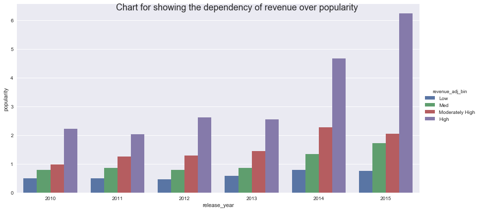

```python
#Referred to Stack overflow for this sns plot creation
lm=sns.factorplot(x='release_year',y='popularity',hue='revenue_adj_bin',kind='bar',data=movie_with_popularity_rev,size=6,aspect=2);
fig = lm.fig

# Add a title to the Figure
fig.suptitle('Chart for showing the dependency of revenue over popularity', fontsize=18)

# Show the plot
plt.show()
```

### Observation

From the above graph, we can make out that the populairty is directly porportional to the revenue category. Films which are having high profit are the ones which have high popularity We can further check with the Voting average value as well

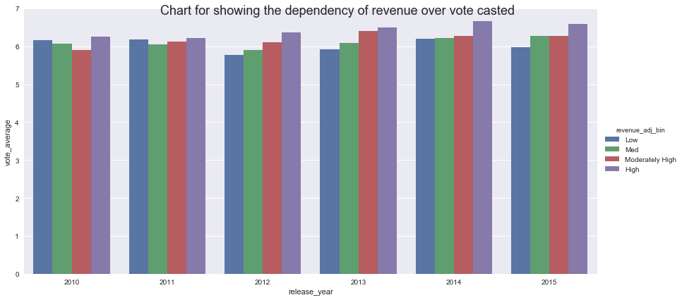

```python
lm=sns.factorplot(x='release_year',y='vote_average',hue='revenue_adj_bin',kind='bar',data=movie_with_voting_rev,size=6,aspect=2);
fig = lm.fig

# Add a title to the Figure
fig.suptitle('Chart for showing the dependency of revenue over vote casted', fontsize=18)

# Show the plot
plt.show()
```

```python
#Check the budget against the popularity & rating seperately (Conside the average value)
movie_with_popularity_bud=movie_valid_df.groupby(['release_year','budget_adj_bin'])['popularity']. mean().reset_index()
movie_with_voting_bud=movie_valid_df.groupby(['release_year','budget_adj_bin'])['vote_average']. mean().reset_index()
```

```python
#Restricting the data as it is too cluster to see
movie_with_popularity_bud=movie_with_popularity_bud.query('release_year >= 2010')
movie_with_voting_bud=movie_with_voting_bud.query('release_year >= 2010')
```

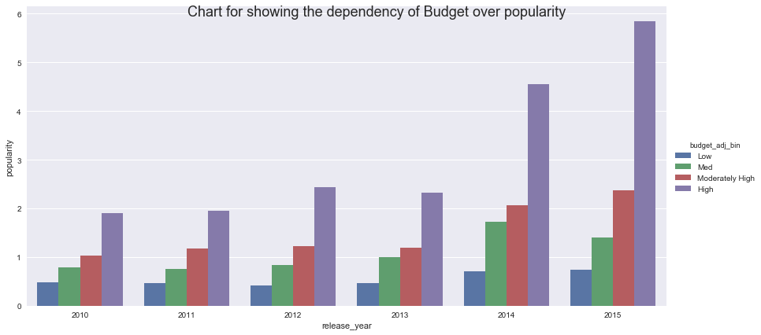

```python
lm=sns.factorplot(x='release_year',y='popularity',hue='budget_adj_bin',kind='bar',data=movie_with_popularity_bud,size=6,aspect=2);
fig = lm.fig

# Add a title to the Figure
fig.suptitle('Chart for showing the dependency of Budget over popularity', fontsize=18)

# Show the plot
plt.show()
```

## Conclusions

By looking in to the budget aspect of the films, we can see that the films which are having high budget are often treated and recieved well from the audience

### Limitations

There is more than 50% of data is having missing budget and revenue information which has caused truncating or limiting the entire data to half od it only.

Thought of imputing the value for revenue in the data but, the mean imputation might not be correct as there will be some movies with star cast , good director and high budget can yield high profits and others might just simply work on the story. It is hard to do the imputation only based on mean, hence i have not done the imputation.

If we could have the data for 50%, then the analysis of factors influencing profit can be more analyzed.

## Submitting your Project

> Before you submit your project, you need to create a .html or .pdf version of this notebook in the workspace here. To do that, run the code cell below. If it worked correctly, you should get a return code of 0, and you should see the generated .html file in the workspace directory (click on the orange Jupyter icon in the upper left).

> Alternatively, you can download this report as .html via the **File** > **Download as** submenu, and then manually upload it into the workspace directory by clicking on the orange Jupyter icon in the upper left, then using the Upload button.

> Once you've done this, you can submit your project by clicking on the "Submit Project" button in the lower right here. This will create and submit a zip file with this .ipynb doc and the .html or .pdf version you created. Congratulations!